# DPS Assignemnt1

Importing cs files from document

```r
#install.packages("dplyr")
#install.packages(c("ggplot2", "ggpubr", "tidyverse", "broom", "AICcmodavg"))

library(dplyr)
#library(ggpubr)
#library(tidyverse)
#library(broom)
#library(AICcmodavg)
library(ggplot2)
library(stats)
```

we sent 0 for article setting and 1 for new settings

```r
hibench_Kmean_6nodes_article_settings <- read.csv("../experiments/hibench_5workers1master_original.report", sep="")
hibench_Kmean_6nodes_new_settings <- read.csv("../experiments/hibench_5workers1master.report", sep="")

hibench_Kmean_6nodes_article_settings["node_numb"] <- "5"
hibench_Kmean_6nodes_article_settings["settings"]<- "0"

hibench_Kmean_6nodes_new_settings["node_numb"] <- "5"
hibench_Kmean_6nodes_new_settings["settings"]<- "1"


hibench_Kmean_11nodes_article_settings <- read.csv("../experiments/hibench_10workers1master_original.report", sep="")
hibench_Kmean_11nodes_new_settings <- read.csv("../experiments/hibench_10workers1master.report", sep="")


hibench_Kmean_11nodes_new_settings["node_numb"] <- "10"
hibench_Kmean_11nodes_new_settings["settings"]<- "1"

hibench_Kmean_11nodes_article_settings["node_numb"] <- "10"
hibench_Kmean_11nodes_article_settings["settings"] <- "0"



hibench_Kmeans_15nodes_article_settings <- read.csv("../experiments/hibench_15workers1master_original.report", sep="")
hibench_Kmeans_15nodes_new_settings <- read.csv("../experiments/hibench_15workers1master.report", sep="")

hibench_Kmeans_15nodes_new_settings["node_numb"] <- "15"
hibench_Kmeans_15nodes_new_settings["settings"]<- "1"

hibench_Kmeans_15nodes_article_settings["node_numb"] <- "15"
hibench_Kmeans_15nodes_article_settings["settings"] <- "0"
```

we sent 0 for article setting and 1 for new settings

```r
hibench_Wordcount_small_article_settings <- read.csv("../experiments/hibench_wordcount_14workers_1master_original_small.report", sep="")
hibench_Wordcount_small_new_settings <- read.csv("../experiments/hibench_wordcount_14workers_1master_small_new.report", sep="")

hibench_Wordcount_small_article_settings["dataset"] <- "0.32GB"
hibench_Wordcount_small_article_settings["settings"]<- "0"

hibench_Wordcount_small_new_settings["dataset"] <- "0.32GB"
hibench_Wordcount_small_new_settings["settings"]<- "1"


hibench_Wordcount_large_article_settings <- read.csv("../experiments/hibench_wordcount_14workers_1master_original_large.report", sep="")
hibench_Wordcount_large_new_settings <- read.csv("../experiments/hibench_wordcount_14workers_1master_new_large.report", sep="")

hibench_Wordcount_large_article_settings["dataset"] <- "3.2GB"
hibench_Wordcount_large_article_settings["settings"]<- "0"

hibench_Wordcount_large_new_settings["dataset"] <- "3.2GB"
hibench_Wordcount_large_new_settings["settings"]<- "1"

hibench_Wordcount_huge_article_settings <- read.csv("../experiments/hibench_wordcount_14workers_1master_original_huge.report", sep="")
hibench_Wordcount_huge_new_settings <- read.csv("../experiments/hibench_wordcount_14workers_1master_new_huge.report", sep="")

hibench_Wordcount_huge_article_settings["dataset"] <- "32GB"
hibench_Wordcount_huge_article_settings["settings"]<- "0"

hibench_Wordcount_huge_new_settings["dataset"] <- "32GB"
hibench_Wordcount_huge_new_settings["settings"]<- "1"
```

Summary statistics are located at the end of the file

joining dfs together

```r
df_article_settings = rbind(hibench_Kmean_11nodes_article_settings, hibench_Kmean_6nodes_article_settings, hibench_Kmeans_15nodes_article_settings)
df_new_setting = rbind(hibench_Kmean_11nodes_new_settings, hibench_Kmean_6nodes_new_settings, hibench_Kmeans_15nodes_new_settings)


df_article_settings_box = df_article_settings
df_new_settings_box = df_new_setting

df_article_settings_bar = df_article_settings
df_new_settings_bar = df_new_setting



df_article_settings_e2 = rbind(hibench_Wordcount_large_article_settings, hibench_Wordcount_small_article_settings, hibench_Wordcount_huge_article_settings)
df_new_setting_e2 = rbind(hibench_Wordcount_large_new_settings, hibench_Wordcount_small_new_settings, hibench_Wordcount_huge_new_settings)


df_article_settings_box_e2 = df_article_settings_e2
df_new_settings_box_e2 = df_new_setting_e2

df_article_settings_bar_e2 = df_article_settings_e2
df_new_settings_bar_e2 = df_new_setting_e2


df_stat_test_e2 = rbind(df_article_settings_bar_e2, df_new_settings_bar_e2)
```

now create 2 box plots - for Experment 1

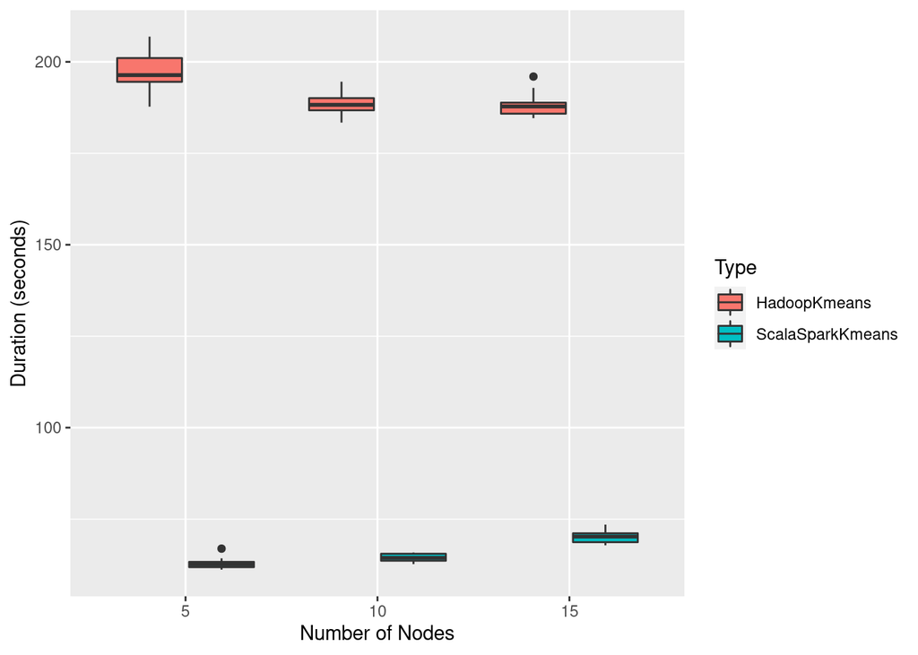

```r
article_setting_box <- ggplot(df_article_settings_box, aes(x = node_numb, y = Duration.s., fill= Type)) +
  geom_boxplot() + xlab("Number of Nodes") + ylab("Duration (seconds)") + scale_x_discrete(limits=c("5","10","15")) #+ expand_limits(x = 0, y = 0)# + ggtitle("K-means performace with Article Settings")

article_setting_box
```

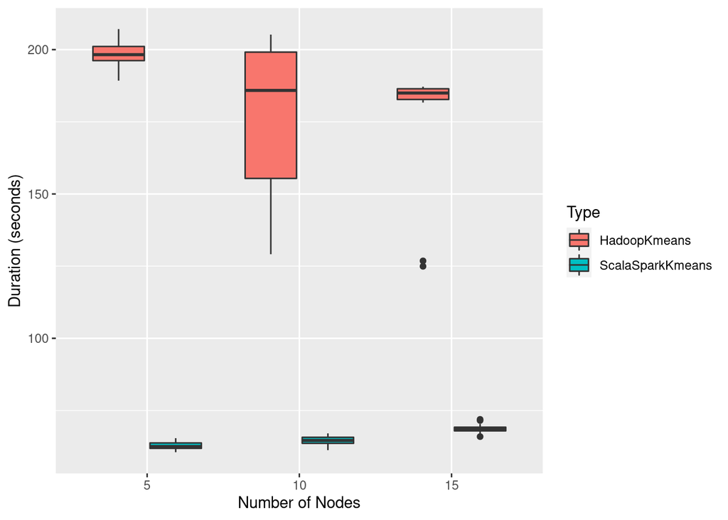

```r
new_setting_box <- ggplot(df_new_settings_box, aes(x = node_numb, y =Duration.s., fill= Type)) +
  geom_boxplot()   + xlab("Number of Nodes") + ylab("Duration (seconds)") + scale_x_discrete(limits=c("5","10","15")) #+ expand_limits(x = 0, y = 0) #+ ggtitle("K-means performace with Our Settings")

new_setting_box
```

2 box plot for experment 2

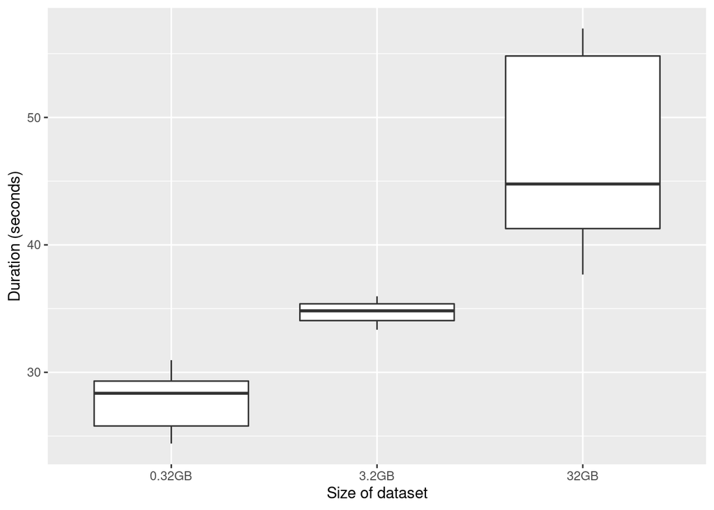

```r
article_setting_box <- ggplot(df_article_settings_box_e2, aes(x = dataset, y = Duration.s.)) +
  geom_boxplot() + xlab("Size of dataset") + ylab("Duration (seconds)") + scale_x_discrete(limits=c("0.32GB","3.2GB","32GB")) #+ expand_limits(x = 0, y = 0)# + ggtitle("Word count performance with Article Settings")


article_setting_box
```

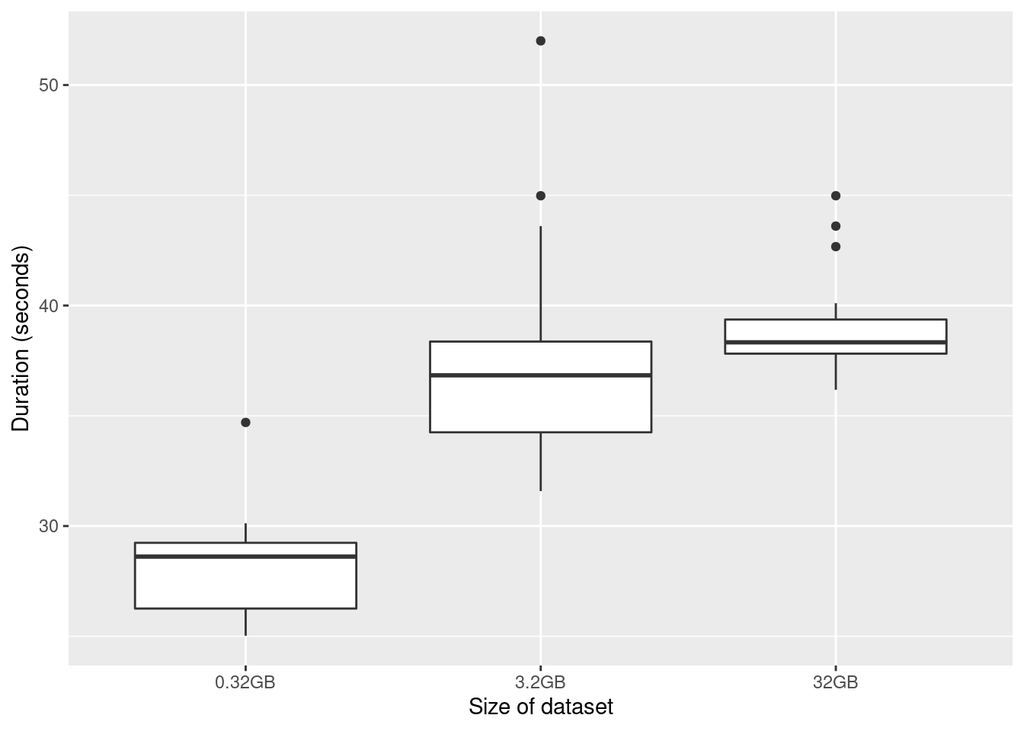

```r
new_setting_box <- ggplot(df_new_settings_box_e2, aes(x = dataset, y =Duration.s.)) +
  geom_boxplot()   + xlab("Size of dataset") + ylab("Duration (seconds)") + scale_x_discrete(limits=c("0.32GB","3.2GB","32GB")) #+ expand_limits(x = 0, y = 0)#+ ggtitle("Word count performace with Our Settings")

new_setting_box
```

Since i dont want to go to bottom of page I dont to see if duration is stat diff in gb size

```r
two.anova_GBdiff = aov(Duration.s. ~ dataset + settings, data=df_stat_test_e2)


summary(two.anova_GBdiff)
```

```
##              Df Sum Sq Mean Sq F value Pr(>F)
## dataset       2   4560  2279.9 127.941 <2e-16 ***
## settings      1     60    60.2   3.381 0.0681 .
## Residuals   136   2424    17.8
## ---
## Signif. codes:  0 '***' 0.001 '**' 0.01 '*' 0.05 '.' 0.1 ' ' 1
```

```r
TukeyHSD(two.anova_GBdiff)
```

```
##   Tukey multiple comparisons of means
##     95% family-wise confidence level
##
## Fit: aov(formula = Duration.s. ~ dataset + settings, data = df_stat_test_e2)
##
## $dataset
##                   diff       lwr       upr p adj
## 3.2GB-0.32GB  8.237867  6.195965 10.279769     0
## 32GB-0.32GB  15.071400 12.834609 17.308191     0
## 32GB-3.2GB    6.833533  4.791631  8.875435     0
##
## $settings
##          diff       lwr       upr     p adj
## 1-0 -1.307036 -2.732739 0.1186673 0.0720433
```

bar plot

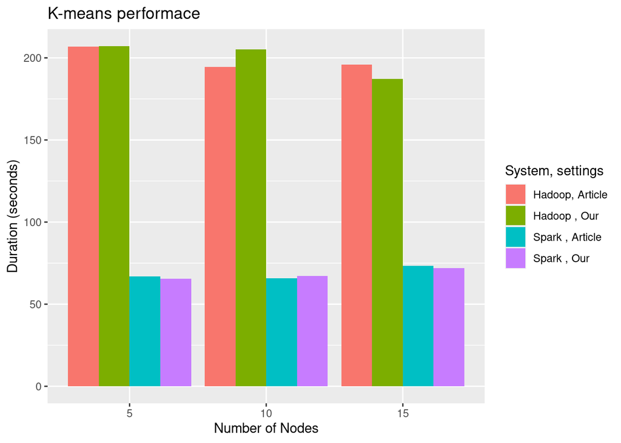

```r
df_bar = rbind(df_article_settings_bar, df_new_settings_bar)
df_bar["comb_settings"] <- paste(df_bar$Type , df_bar$settings)




article_setting_bar <- ggplot(df_bar, aes(x = node_numb, y=Duration.s., fill = comb_settings)) + geom_bar(stat="identity" , position='dodge') +
  ggtitle("K-means performace ") + ylab("Duration (seconds)") + scale_x_discrete(limits=c("5","10","15"), name="Number of Nodes") +
  scale_fill_discrete(name="System, settings", labels = c("Hadoop, Article", "Hadoop , Our", "Spark , Article", "Spark , Our"))




article_setting_bar
```

okay now need a ANOVA H0: The means are equal for varables H1: The means are different

```r
df_stat = df_bar



df_stat["comb_settings_nodes"] = paste(df_stat$Type, df_stat$settings ,df_stat$node_numb)

df_stat_test <- data.frame( df_stat$Duration.s.,  df_stat$comb_settings_nodes)
colnames(df_stat_test) <- c("Duration.s." , "comb_settings_nodes" )

one.way <- aov(Duration.s. ~ comb_settings_nodes, data = df_stat_test)

print("duration for combo stat of combo setting nodes")
```

```
## [1] "duration for combo stat of combo setting nodes"
```

```r
summary(one.way)
```

```
##                      Df Sum Sq Mean Sq F value Pr(>F)
## comb_settings_nodes  11 904290   82208   859.2 <2e-16 ***
## Residuals           228  21814      96
## ---
## Signif. codes:  0 '***' 0.001 '**' 0.01 '*' 0.05 '.' 0.1 ' ' 1
```

So we find statistically significant difference between our treament set of setting, nodes, and System. We would now like to know is there a statically different results in our setting from the authors

H0 : The means are equal for both variables H1 ; the means are different for both variables

```r
df_stat2 = df_bar

df_stat2["comb_nodes"] = paste(df_stat$Type , df_stat$node_numb)

df_stat_test <- data.frame( df_stat2$Duration.s.,  df_stat2$comb_nodes , df_stat2$settings, df_stat2$node_numb, df_stat2$Type)
colnames(df_stat_test) <- c("Duration.s." , "comb_nodes" ,"settings", "node_numb", "system_type")
```

```r
one.way_nodenumber <- aov(Duration.s. ~ node_numb * system_type, data = df_stat_test)

print("does the mean different with node number")
```

```
## [1] "does the mean different with node number"
```

```r
summary(one.way_nodenumber)
```

```
##                        Df Sum Sq Mean Sq  F value   Pr(>F)
## node_numb               2   2016    1008    9.696 9.01e-05 ***
## system_type             1 894694  894694 8606.785  < 2e-16 ***
## node_numb:system_type   2   5070    2535   24.385 2.40e-10 ***
## Residuals             234  24325     104
## ---
## Signif. codes:  0 '***' 0.001 '**' 0.01 '*' 0.05 '.' 0.1 ' ' 1
```

```r
TukeyHSD(one.way_nodenumber)
```

```
##   Tukey multiple comparisons of means
##     95% family-wise confidence level
##
## Fit: aov(formula = Duration.s. ~ node_numb * system_type, data = df_stat_test)
##
## $node_numb
##           diff         lwr       upr     p adj
## 15-10 3.245800 -0.55665573  7.048256 0.1112144
## 5-10  7.090538  3.28808177 10.892993 0.0000491
## 5-15  3.844737  0.04228177  7.647193 0.0468316
##
## $system_type
##                                    diff       lwr       upr p adj
## ScalaSparkKmeans-HadoopKmeans -122.1129 -124.7062 -119.5197     0
##
## $`node_numb:system_type`
##                                                diff         lwr           upr
## 15:HadoopKmeans-10:HadoopKmeans            1.543175   -5.007879    8.09422876
## 5:HadoopKmeans-10:HadoopKmeans            15.876925    9.325871   22.42797876
## 10:ScalaSparkKmeans-10:HadoopKmeans     -117.390425 -123.941479 -110.83937124
## 15:ScalaSparkKmeans-10:HadoopKmeans     -112.442000 -118.993054 -105.89094624
## 5:ScalaSparkKmeans-10:HadoopKmeans      -119.086275 -125.637329 -112.53522124
## 5:HadoopKmeans-15:HadoopKmeans            14.333750    7.782696   20.88480376
## 10:ScalaSparkKmeans-15:HadoopKmeans     -118.933600 -125.484654 -112.38254624
## 15:ScalaSparkKmeans-15:HadoopKmeans     -113.985175 -120.536229 -107.43412124
## 5:ScalaSparkKmeans-15:HadoopKmeans      -120.629450 -127.180504 -114.07839624
## 10:ScalaSparkKmeans-5:HadoopKmeans      -133.267350 -139.818404 -126.71629624
## 15:ScalaSparkKmeans-5:HadoopKmeans      -128.318925 -134.869979 -121.76787124
## 5:ScalaSparkKmeans-5:HadoopKmeans       -134.963200 -141.514254 -128.41214624
## 15:ScalaSparkKmeans-10:ScalaSparkKmeans    4.948425   -1.602629   11.49947876
## 5:ScalaSparkKmeans-10:ScalaSparkKmeans    -1.695850   -8.246904    4.85520376
## 5:ScalaSparkKmeans-15:ScalaSparkKmeans    -6.644275  -13.195329   -0.09322124
##                                             p adj
## 15:HadoopKmeans-10:HadoopKmeans         0.9843417
## 5:HadoopKmeans-10:HadoopKmeans          0.0000000
## 10:ScalaSparkKmeans-10:HadoopKmeans     0.0000000
## 15:ScalaSparkKmeans-10:HadoopKmeans     0.0000000
## 5:ScalaSparkKmeans-10:HadoopKmeans      0.0000000
## 5:HadoopKmeans-15:HadoopKmeans          0.0000000
## 10:ScalaSparkKmeans-15:HadoopKmeans     0.0000000
## 15:ScalaSparkKmeans-15:HadoopKmeans     0.0000000
## 5:ScalaSparkKmeans-15:HadoopKmeans      0.0000000
## 10:ScalaSparkKmeans-5:HadoopKmeans      0.0000000
## 15:ScalaSparkKmeans-5:HadoopKmeans      0.0000000
## 5:ScalaSparkKmeans-5:HadoopKmeans       0.0000000
## 15:ScalaSparkKmeans-10:ScalaSparkKmeans 0.2556003
## 5:ScalaSparkKmeans-10:ScalaSparkKmeans  0.9761737
## 5:ScalaSparkKmeans-15:ScalaSparkKmeans  0.0446591
```

We want to see if our setting matter

```r
one.way_settings <- aov(Duration.s. ~ settings + ( system_type + node_numb), data = df_stat_test)

print("mean of setting a data for duration is statically different ")
```

```
## [1] "mean of setting a data for duration is statically different "
```

```r
summary(one.way_settings)
```

```
##              Df Sum Sq Mean Sq  F value   Pr(>F)
## settings      1    785     785    6.452 0.011731 *
## system_type   1 894694  894694 7349.137  < 2e-16 ***
## node_numb     2   2016    1008    8.279 0.000335 ***
## Residuals   235  28609     122
## ---
## Signif. codes:  0 '***' 0.001 '**' 0.01 '*' 0.05 '.' 0.1 ' ' 1
```

```r
TukeyHSD(one.way_settings)
```

```
##   Tukey multiple comparisons of means
##     95% family-wise confidence level
##
## Fit: aov(formula = Duration.s. ~ settings + (system_type + node_numb), data = df_stat_test)
##
## $settings
##          diff       lwr        upr     p adj
## 1-0 -3.618067 -6.424366 -0.8117675 0.0117308
##
## $system_type
##                                    diff       lwr       upr p adj
## ScalaSparkKmeans-HadoopKmeans -122.1129 -124.9192 -119.3066     0
##
## $node_numb
##           diff        lwr       upr     p adj
## 15-10 3.245800 -0.8690559  7.360656 0.1525809
## 5-10  7.090538  2.9756816 11.205393 0.0001936
## 5-15  3.844738 -0.2701184  7.959593 0.0725995
```

They do but are not a constent if we look at bar graph

```r
#one.way_plus_sys <- aov(Duration.s. ~ node_numb + system_type , data = df_stat_test)

#summary(one.way_plus_sys)

#TukeyHSD(one.way_plus_sys)
```

If we now just a T-Test between each of the system types we can conclude spark is faster then Hadoop on K-means

```r
t.test(Duration.s. ~ system_type , data = df_stat_test)
```

```
##
##  Welch Two Sample t-test
##
## data:  Duration.s. by system_type
## t = 82.336, df = 128.4, p-value < 2.2e-16
## alternative hypothesis: true difference in means is not equal to 0
## 95 percent confidence interval:
##  119.1784 125.0474
## sample estimates:
##     mean in group HadoopKmeans mean in group ScalaSparkKmeans
##                      187.68895                       65.57602
```

```r
t.test(Duration.s. ~ settings, data = df_stat_test)
```

```
##
##  Welch Two Sample t-test
##
## data:  Duration.s. by settings
## t = 0.44946, df = 237.87, p-value = 0.6535
## alternative hypothesis: true difference in means is not equal to 0
## 95 percent confidence interval:
##  -12.23981  19.47594
## sample estimates:
## mean in group 0 mean in group 1
##        128.4415        124.8234
```

Summary statics about mean deuration for each type of treatment

```r
df_sum_stat <- subset(df_bar, select = -c(Date , Time))

print(summary(df_sum_stat))
```

```
##                Type     Input_data_size      Duration.s.
##  HadoopKmeans    :120   Min.   :4.016e+09   Min.   : 60.54
##  ScalaSparkKmeans:120   1st Qu.:4.016e+09   1st Qu.: 64.70
##                         Median :4.016e+09   Median : 99.22
##                         Mean   :4.016e+09   Mean   :126.63
##                         3rd Qu.:4.016e+09   3rd Qu.:188.85
##                         Max.   :4.016e+09   Max.   :207.12
##  Throughput.bytes.s. Throughput.node     node_numb           settings
##  Min.   :19391613    Min.   : 1366266   Length:240         Length:240
##  1st Qu.:21267950    1st Qu.: 2146131   Class :character   Class :character
##  Median :43393613    Median : 4453960   Mode  :character   Mode  :character
##  Mean   :41492966    Mean   : 5812798
##  3rd Qu.:62078040    3rd Qu.: 6224378
##  Max.   :66341349    Max.   :16585337
##  comb_settings
##  Length:240
##  Class :character
##  Mode  :character
##
##
##
```

```r
aggregate(df_sum_stat$Duration.s., list(df_sum_stat$Type), median)
```

| Group.1 | x |
| --- | --- |
| HadoopKmeans | 188.9025 |
| ScalaSparkKmeans | 64.6975 |

```r
aggregate(df_sum_stat$Duration.s., list(df_sum_stat$node_numb, df_sum_stat$Type, df_sum_stat$settings ), median)
```

| Group.1 | Group.2 | Group.3 | x |
| --- | --- | --- | --- |
| 10 | HadoopKmeans | 0 | 188.2520 |
| 15 | HadoopKmeans | 0 | 187.8075 |
| 5 | HadoopKmeans | 0 | 196.3805 |
| 10 | ScalaSparkKmeans | 0 | 64.4080 |
| 15 | ScalaSparkKmeans | 0 | 70.2225 |
| 5 | ScalaSparkKmeans | 0 | 62.6430 |
| 10 | HadoopKmeans | 1 | 185.8700 |
| 15 | HadoopKmeans | 1 | 184.9575 |
| 5 | HadoopKmeans | 1 | 198.2615 |
| 10 | ScalaSparkKmeans | 1 | 64.6250 |

[output cut: 2 more lines]

```r
#aggregate(df_sum_stat$Duration.s., list(df_sum_stat$node_numb, df_sum_stat$Type, df_sum_stat$settings ), count)

#aggregate(hibench_Kmeans_15nodes_article_settings$Duration.s., list(hibench_Kmeans_15nodes_article_settings$Type), median)
```